# Imports

```python
import pandas as pd
import matplotlib.pyplot as plt
import seaborn as sns
import numpy as np
import scipy.stats as stats

from scipy.stats import skew, kurtosis
from sklearn.neighbors import KNeighborsClassifier
from sklearn.metrics import accuracy_score, classification_report, confusion_matrix, silhouette_score
from sklearn.preprocessing import StandardScaler, MinMaxScaler
from sklearn.model_selection import StratifiedKFold, cross_val_score, GridSearchCV, train_test_split
from sklearn.naive_bayes import GaussianNB, BernoulliNB
from sklearn.pipeline import Pipeline
from sklearn.cluster import KMeans, AgglomerativeClustering
from scipy.cluster.hierarchy import linkage, dendrogram

import time

%matplotlib inline
```

### Data

```python
path = "data/Mall_Customers.csv"
mall = pd.read_csv(path)

# Dropping the index
mall.drop('CustomerID', axis = 1, inplace = True)
mall.head()
```

|  | Genre | Age | Annual Income (k$) | Spending Score (1-100) |
| --- | --- | --- | --- | --- |
| 0 | Male | 19 | 15 | 39 |
| 1 | Male | 21 | 15 | 81 |
| 2 | Female | 20 | 16 | 6 |
| 3 | Female | 23 | 16 | 77 |
| 4 | Female | 31 | 17 | 40 |

```python
len(mall)
```

```
200
```

# Summary

# Exploring

```python
mall.head()
```

|  | Genre | Age | Annual Income (k$) | Spending Score (1-100) |
| --- | --- | --- | --- | --- |
| 0 | Male | 19 | 15 | 39 |
| 1 | Male | 21 | 15 | 81 |
| 2 | Female | 20 | 16 | 6 |
| 3 | Female | 23 | 16 | 77 |
| 4 | Female | 31 | 17 | 40 |

```python
mall.tail()
```

|  | Genre | Age | Annual Income (k$) | Spending Score (1-100) |
| --- | --- | --- | --- | --- |
| 195 | Female | 35 | 120 | 79 |
| 196 | Female | 45 | 126 | 28 |
| 197 | Male | 32 | 126 | 74 |
| 198 | Male | 32 | 137 | 18 |
| 199 | Male | 30 | 137 | 83 |

```python
mall.info()
```

```
<class 'pandas.core.frame.DataFrame'>
RangeIndex: 200 entries, 0 to 199
Data columns (total 4 columns):
 #   Column                  Non-Null Count  Dtype
---  ------                  --------------  -----
 0   Genre                   200 non-null    object
 1   Age                     200 non-null    int64
 2   Annual Income (k$)      200 non-null    int64
 3   Spending Score (1-100)  200 non-null    int64
dtypes: int64(3), object(1)
memory usage: 6.4+ KB
```

```python
mall.describe()
```

|  | Age | Annual Income (k$) | Spending Score (1-100) |
| --- | --- | --- | --- |
| count | 200.000000 | 200.000000 | 200.000000 |
| mean | 38.850000 | 60.560000 | 50.200000 |
| std | 13.969007 | 26.264721 | 25.823522 |
| min | 18.000000 | 15.000000 | 1.000000 |
| 25% | 28.750000 | 41.500000 | 34.750000 |
| 50% | 36.000000 | 61.500000 | 50.000000 |
| 75% | 49.000000 | 78.000000 | 73.000000 |
| max | 70.000000 | 137.000000 | 99.000000 |

```python
# Making column names a little easier to work with
mall.columns = ['gender', 'age', 'income', 'spending_score']
```

I'm going to bin the spending score column. This will be the target for classification. I'll view the data first to see what we're working with.

### Binning spending score for supervised clustering algos.

```python
mall.spending_score.describe()
```

```
count    200.000000
mean      50.200000
std       25.823522
min        1.000000
25%       34.750000
50%       50.000000
75%       73.000000
max       99.000000
Name: spending_score, dtype: float64
```

```python
mall.spending_score.mode()
```

```
0    42
Name: spending_score, dtype: int64
```

```
Skewness: -0.05
Kurtosis: -0.84
```

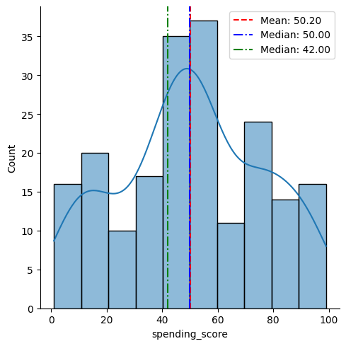

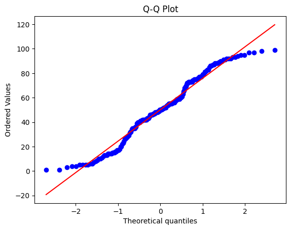

```python
g = sns.displot(mall.spending_score, kde=True, bins = 10)

mean_val = np.mean(mall.spending_score)
median_val = np.median(mall.spending_score)
mode_val = mall.spending_score.mode()[0]
skewness = skew(mall.spending_score)
kurt = kurtosis(mall.spending_score)

for ax in g.axes.flat:
    ax.axvline(mean_val, color='red', linestyle='--', label=f'Mean: {mean_val:.2f}')
    ax.axvline(median_val, color='blue', linestyle='-.', label=f'Median: {median_val:.2f}')
    ax.axvline(mode_val, color='green', linestyle='-.', label=f'Median: {mode_val:.2f}')
ax.legend()

# Print skewness and kurtosis
print(f"Skewness: {skewness:.2f}")
print(f"Kurtosis: {kurt:.2f}")

plt.figure()
stats.probplot(mall.spending_score, dist="norm", plot=plt)
plt.title("Q-Q Plot")
plt.show()
```

Hah. This is a strange spread of values. The spending scores are distributed in clusters rather than a normal distribution.  
The funny part is the clusters nearly cancel each other out. The skew value is nearly 0 because the clusters at the right and left edges perfectly balance each other. And then its also kinda flat but has the peak in the middle of the flat parts.  
Almost like a middle finger.  
It's not a very good normal distribution, but it should be good enough to evenly bin the data by quantile.

```python
qvalues = list(mall.spending_score.quantile([.33, .67]))
print(f'Low spending score is considered <= {qvalues[0]} \n'
      f'Medium is a spending score greater than {qvalues[0]} and less than or equal to {qvalues[1]:.2f}\n'
      f'High is any spending score greater than {qvalues[1]:.2f}.')
```

```
Low spending score is considered <= 41.0
Medium is a spending score greater than 41.0 and less than or equal to 59.00
High is any spending score greater than 59.00.
```

```python
quantile = pd.qcut(mall.spending_score, q=3, labels = ['low', 'medium', 'high'])

mall['spending_level'] = quantile
print("Number of values per class:")
print(quantile.value_counts())

low = quantile.value_counts()['low']
low = quantile.value_counts()['medium']
```

```
Number of values per class:
spending_score
medium    68
low       67
high      65
Name: count, dtype: int64
```

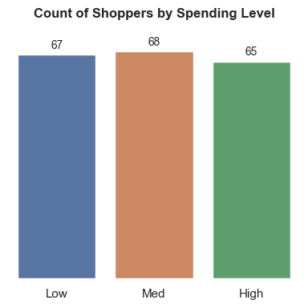

```python
sns.set_theme(style = 'white')

fig, ax = plt.subplots(figsize=(4, 4))

sns.countplot(data = mall, x = 'spending_level', hue = 'spending_level')
sns.despine(trim = True)

for c in ax.containers:
    ax.bar_label(c, padding=3, fontsize = 10)
ax.set_xticklabels(['Low', 'Med', 'High'])
ax.set_xlabel('')
ax.set_ylabel('')
ax.set_yticklabels([])
sns.despine(ax=ax, left=True, bottom=True, right=True, top=True)
ax.set_title('Count of Shoppers by Spending Level', pad = 20, fontsize = 12, weight = 'bold')

plt.tight_layout()
plt.show()
```

Cool. A nice even split.

# Visualising

I'll take a peek at the income column first.

```
Skewness: 0.32
Kurtosis: -0.13
```

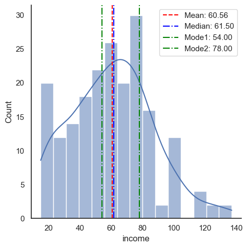

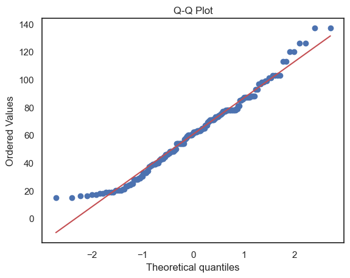

```python
g = sns.displot(mall.income, kde=True, bins = 15)

mean_val = np.mean(mall.income)
median_val = np.median(mall.income)
mode_val1 = mall.income.mode()[0]
mode_val2 = mall.income.mode()[1]
skewness = skew(mall.income)
kurt = kurtosis(mall.income)

for ax in g.axes.flat:
    ax.axvline(mean_val, color='red', linestyle='--', label=f'Mean: {mean_val:.2f}')
    ax.axvline(median_val, color='blue', linestyle='-.', label=f'Median: {median_val:.2f}')
    ax.axvline(mode_val1, color='green', linestyle='-.', label=f'Mode1: {mode_val1:.2f}')
    ax.axvline(mode_val2, color='green', linestyle='-.', label=f'Mode2: {mode_val2:.2f}')

ax.legend()

# Print skewness and kurtosis
print(f"Skewness: {skewness:.2f}")
print(f"Kurtosis: {kurt:.2f}")

plt.figure()
stats.probplot(mall.income, dist="norm", plot=plt)
plt.title("Q-Q Plot")
plt.show()
```

Little right skewed, but not too bad. Still definitely not a great normal curve.

I'll plot income vs spending_score. Maybe there will be a direct correlation and we won't need an ML model?

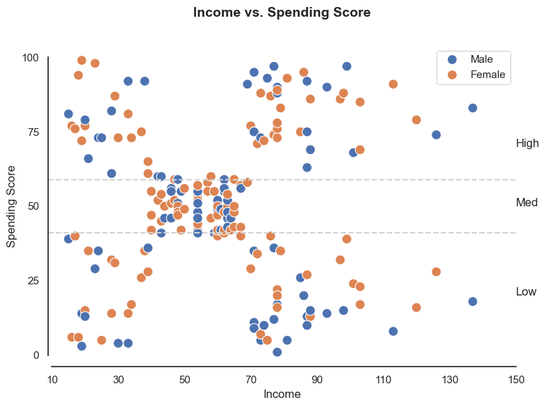

```python
sns.set_theme(style="white")

fig, ax = plt.subplots(figsize=(8, 6))

sns.scatterplot(
    data=mall,
    x='income',
    y='spending_score',
    s=100,
    hue="gender",
    ax=ax
)


ax.set_title("Income vs. Spending Score", pad=30, fontsize=14, weight = 'bold')
ax.set_xlabel("Income", fontsize=12)
ax.set_ylabel("Spending Score", fontsize=12)
ax.set_xticks(range(10, 151, 20))
ax.set_xticklabels(list(range(10, 151, 20)))

#ax.tick_params(axis='x', which='both', bottom=True, top=False, labelbottom=False)

ax.set_yticks([0, 25, 50, 75, 100])
ax.set_yticklabels([0, 25, 50, 75, 100])


for i in [0,1]:
    ax.axhline(qvalues[i], color = 'lightgrey', linestyle='--')

ax.text(x = 150, y = 20, s = "Low")
ax.text(x = 150, y = 50, s = "Med")
ax.text(x = 150, y = 70, s = "High")

#ax.tick_params(axis='y', which='both', left=True, right=False, labelleft=False)

ax.legend()
sns.despine(ax=ax, trim=True)


plt.tight_layout()
plt.show()
```

This looks to be about 0 correlation. Let's check...

```python
mall.income.corr(mall.spending_score)
```

```
np.float64(0.009902848094037606)
```

Yup! How about age and spending score?

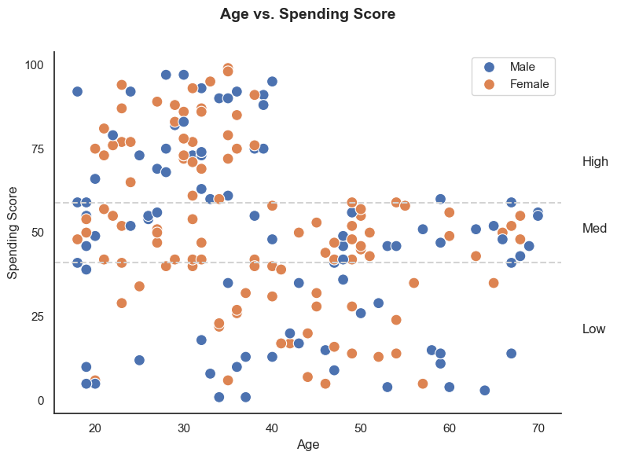

```python
sns.set_theme(style="white")

fig, ax = plt.subplots(figsize=(8, 6))

sns.scatterplot(
    data=mall,
    x='age',
    y='spending_score',
    s=100,
    hue="gender",
    ax=ax
)


ax.set_title("Age vs. Spending Score", pad=30, fontsize=14, weight = 'bold')
ax.set_xlabel("Age", fontsize=12)
ax.set_ylabel("Spending Score", fontsize=12)

#ax.tick_params(axis='x', which='both', bottom=True, top=False, labelbottom=False)

ax.set_yticks([0, 25, 50, 75, 100])
ax.set_yticklabels([0, 25, 50, 75, 100])

#ax.tick_params(axis='y', which='both', left=True, right=False, labelleft=False)

for i in [0,1]:
    ax.axhline(qvalues[i], color = 'lightgrey', linestyle='--')

ax.text(x = 75, y = 20, s = "Low")
ax.text(x = 75, y = 50, s = "Med")
ax.text(x = 75, y = 70, s = "High")


ax.legend()
sns.despine(ax=ax)


plt.tight_layout()
plt.show()
```

This is interesting. It seems like age and spending score may be inversely correlated.

```python
mall.age.corr(mall.spending_score)
```

```
np.float64(-0.32722684603909)
```

Yeah, a slight negative correlation.

Last, I'll take a peek at the spread of gender and ages.

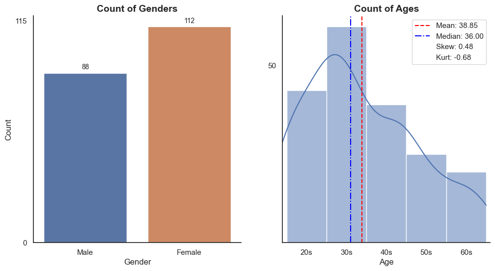

```python
sns.set_theme(style = 'white')

fig, (ax1, ax2) = plt.subplots(1,2, figsize=(12, 6))

sns.countplot(data = mall, x = 'gender', hue = 'gender', ax = ax1)
sns.despine(ax=ax1)
for c in ax1.containers:
    ax1.bar_label(c, padding=3, fontsize = 10)

ax1.set_xlabel("Gender")
ax1.set_ylabel("Count")
ax1.set_title("Count of Genders", fontsize = 14, weight = 'bold')
ax1.set_yticks([0,115])
ax1.set_yticklabels([0,115])


bins = [i*10 for i in range(2, 8)]
bin_ticks = np.array(bins) + 5
bin_labels = [str(i*10)+"s" for i in range(2, 8)]

sns.histplot(data = mall, x = 'age', ax = ax2, kde=True, bins = bins)

ax2.set_ylabel("")
ax2.set_xlabel("Age")
ax2.set_yticks([0,50])
ax2.set_yticklabels(['',50])
ax2.set_xticks(bin_ticks)

ax2.set_xticklabels(labels = bin_labels)
ax2.set_title("Count of Ages", fontsize = 14, weight = 'bold')

ax2.set_xlim(left = 19, right = 71)
sns.despine(ax=ax2)

mean_val = np.mean(mall.age)
median_val = np.median(mall.age)
skewness = skew(mall.age)
kurt = kurtosis(mall.age)


ax2.axvline(mean_val, color='red', linestyle='--', label=f'Mean: {mean_val:.2f}')
ax2.axvline(median_val, color='blue', linestyle='-.', label=f'Median: {median_val:.2f}')
ax2.axvline(skewness, color = 'white', label = f'Skew: {skewness:.2f}')
ax2.axvline(kurt, color = 'white', label = f'Kurt: {kurt:.2f}')
ax2.legend()

plt.show()
```

It looks like there is a fairly balanced split of genders sampled, favoring female.  
Ages are very right skewed though.

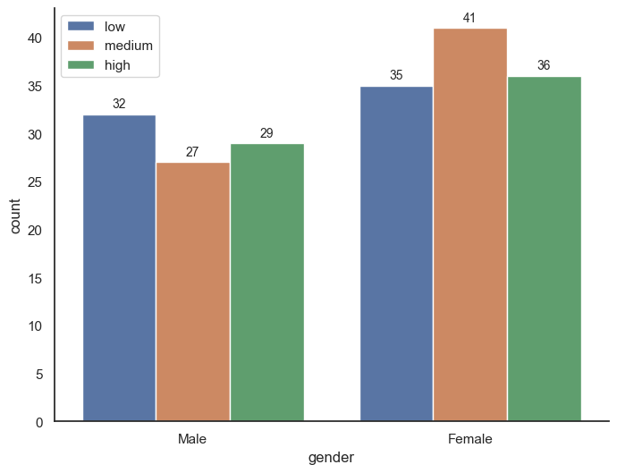

```python
sns.set_theme(style = 'white')

fig, ax = plt.subplots(figsize=(8, 6))

sns.countplot(data = mall, x = 'gender', hue = 'spending_level')
sns.despine(ax=ax)
for c in ax.containers:
    ax.bar_label(c, padding=3, fontsize = 10)

ax1.set_xlabel("Gender")
ax1.set_ylabel("Count")
ax1.set_title("Count of Genders", fontsize = 14, weight = 'bold')
ax.legend()
```

```python
df_m = mall[mall['gender'] == 'Male']
df_f = mall[mall['gender'] == 'Female']
```

```python
df_f['spending_level'].value_counts(sort = False)/len(df_f)
```

```
spending_level
low       0.312500
medium    0.366071
high      0.321429
Name: count, dtype: float64
```

```python
df_m['spending_level'].value_counts(sort = False)/len(df_m)
```

```
spending_level
low       0.363636
medium    0.306818
high      0.329545
Name: count, dtype: float64
```

It seems like Males are very slightly more likely to be rated with a low spending level, while Females are slightly more likely to be rated with a medium spending level.

# Supervised Algorithms

We're using two supervised classification algorithms: K-Nearest Neighbors and Naive Bayes.  
**K-Nearest Neighbors**: Classify based on the majority class "near" the data point  
**Naive Bayes**: Predicts the class that has the highest probability given the input features. See Bayes Theorem.

```python
mall.head()
```

|  | gender | age | income | spending_score | spending_level |
| --- | --- | --- | --- | --- | --- |
| 0 | Male | 19 | 15 | 39 | low |
| 1 | Male | 21 | 15 | 81 | high |
| 2 | Female | 20 | 16 | 6 | low |
| 3 | Female | 23 | 16 | 77 | high |
| 4 | Female | 31 | 17 | 40 | low |

### KNN prep

KNN requires numerical input data and it requires scaling of the numerical columns. I'll use one-hot encoding for gender,

```python
# One hot encoding for gender column
mall_knn = pd.get_dummies(mall, columns = ['gender'])

mall_knn['gender_Female'], mall_knn['gender_Male'] =  mall_knn['gender_Female'].astype(int), mall_knn['gender_Male'].astype(int)
```

```python
mall_knn
```

|  | age | income | spending_score | spending_level | gender_Female | gender_Male |
| --- | --- | --- | --- | --- | --- | --- |
| 0 | 19 | 15 | 39 | low | 0 | 1 |
| 1 | 21 | 15 | 81 | high | 0 | 1 |
| 2 | 20 | 16 | 6 | low | 1 | 0 |
| 3 | 23 | 16 | 77 | high | 1 | 0 |
| 4 | 31 | 17 | 40 | low | 1 | 0 |
| ... | ... | ... | ... | ... | ... | ... |
| 195 | 35 | 120 | 79 | high | 1 | 0 |
| 196 | 45 | 126 | 28 | low | 1 | 0 |
| 197 | 32 | 126 | 74 | high | 0 | 1 |
| 198 | 32 | 137 | 18 | low | 0 | 1 |
| 199 | 30 | 137 | 83 | high | 0 | 1 |

200 rows × 6 columns

Age and Income are normally distributed enough for a StandardScalar.

```python
scaler = StandardScaler()
mall_knn[['age', 'income']] = scaler.fit_transform(mall_knn[['age', 'income']])
```

```python
mall_knn[['age', 'income']].head()
```

|  | age | income |
| --- | --- | --- |
| 0 | -1.424569 | -1.738999 |
| 1 | -1.281035 | -1.738999 |
| 2 | -1.352802 | -1.700830 |
| 3 | -1.137502 | -1.700830 |
| 4 | -0.563369 | -1.662660 |

And finally, we'll map the spending_level classes to integers.  
0 = low  
1 = medium  
2 = high

```python
spend_map = {
    'low': 0,
    'medium': 1,
    'high': 2
}

mall_knn['spending_level'] = mall_knn['spending_level'].map(spend_map)
print(mall_knn['spending_level'].value_counts())
```

```
spending_level
1    68
0    67
2    65
Name: count, dtype: int64
```

**KNN time!**

```python
# Our training and test sets
X = mall_knn[['gender_Male', 'gender_Female', 'age', 'income']].copy()
y = np.array(mall_knn[['spending_level']].copy()).reshape(len(mall_knn),)

X_train, X_test, y_train, y_test = train_test_split(
    X,
    y,
    test_size=0.2,
    random_state = 13,
    stratify = y
)
```

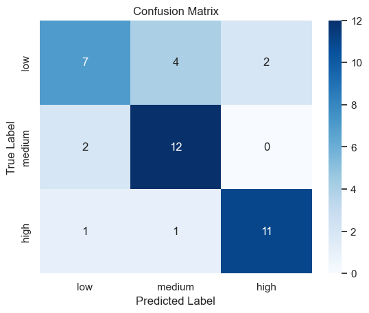

```
              precision    recall  f1-score   support

           0       0.70      0.54      0.61        13
           1       0.71      0.86      0.77        14
           2       0.85      0.85      0.85        13

    accuracy                           0.75        40
   macro avg       0.75      0.75      0.74        40
weighted avg       0.75      0.75      0.74        40

Accuracy: 0.75
```

```python
model = KNeighborsClassifier(n_neighbors=3)
model.fit(X_train, y_train)


y_pred = model.predict(X_test)

classes = spend_map.keys()

cm = confusion_matrix(y_test, y_pred)
sns.heatmap(cm, annot = True, xticklabels =classes, yticklabels = classes, cmap = 'Blues')
plt.xlabel('Predicted Label')
plt.ylabel('True Label')
plt.title('Confusion Matrix')
plt.show()
print(classification_report(y_test, y_pred))

print("Accuracy:", accuracy_score(y_test, y_pred))
```

Eh. It's okay. I'll use cross_validation to check how well the model performs on different subsets.  
Note: I came back later and added the StratiedKFold to make sure my dataset was split into sets with balanced target classes.

```python
cv = StratifiedKFold(n_splits = 5, shuffle = True, random_state = 13)


model = KNeighborsClassifier(n_neighbors=3)
scores = cross_val_score(model, X, y, cv=cv, scoring = 'accuracy' )

print("Cross-validated scores:", scores)
print(f"Mean accuracy: {scores.mean():.2f}")
```

```
Cross-validated scores: [0.7   0.75  0.8   0.675 0.775]
Mean accuracy: 0.74
```

It's okay. Let's try a GridSearch to see if improving n will help.

```python
param_grid = {
    'n_neighbors': list(range(1,25))
}

grid = GridSearchCV(
    estimator = KNeighborsClassifier(),
    param_grid = param_grid,
    cv = cv,
    scoring = 'accuracy',
    n_jobs = -1,
    verbose = 2
)

grid.fit(X_train, y_train)

print("Best parameters found:", grid.best_params_)
print(f"Best CV Score: {grid.best_score_:.4f}")

accuracy = grid.score(X_test, y_test)
print(f"Accuracy: {accuracy:.4f}")
```

```
Fitting 5 folds for each of 24 candidates, totalling 120 fits
Best parameters found: {'n_neighbors': 5}
Best CV Score: 0.7562
Accuracy: 0.8000
```

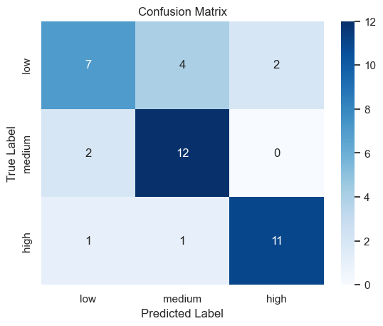

```
              precision    recall  f1-score   support

           0       0.88      0.54      0.67        13
           1       0.72      0.93      0.81        14
           2       0.86      0.92      0.89        13

    accuracy                           0.80        40
   macro avg       0.82      0.80      0.79        40
weighted avg       0.82      0.80      0.79        40
```

```python
pred = grid.predict(X_test)

cm = confusion_matrix(y_test, y_pred)
sns.heatmap(cm, annot = True, xticklabels =classes, yticklabels = classes, cmap = 'Blues')
plt.xlabel('Predicted Label')
plt.ylabel('True Label')
plt.title('Confusion Matrix')
plt.show()

print(classification_report(y_test, pred))
```

Better accuracy but not great at generalizing.  
I'm going to try the other parameters: weights, distance calculation method, and algorithm.

```python
param_grid = {
    'n_neighbors': list(range(1,25)),
    'weights' : ['uniform', 'distance'],
    'p' : [1, 2, 3],
    'algorithm' : ['ball_tree', 'kd_tree', 'brute', 'auto']
}

grid = GridSearchCV(
    estimator = KNeighborsClassifier(),
    param_grid = param_grid,
    cv = cv,
    scoring = 'accuracy',
    n_jobs = -1,
    verbose = 3
)

grid.fit(X_train, y_train)

print("Best parameters found:", grid.best_params_)
print(f"Best CV Score: {grid.best_score_:.4f}")

accuracy = grid.score(X_test, y_test)
print(f"Accuracy: {accuracy:.4f}")
```

```
Fitting 5 folds for each of 576 candidates, totalling 2880 fits
Best parameters found: {'algorithm': 'ball_tree', 'n_neighbors': 3, 'p': 3, 'weights': 'distance'}
Best CV Score: 0.7625
Accuracy: 0.8250
```

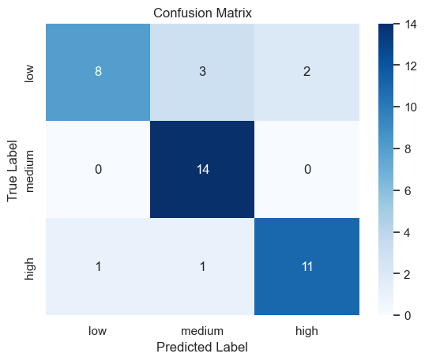

```
              precision    recall  f1-score   support

           0       0.88      0.54      0.67        13
           1       0.72      0.93      0.81        14
           2       0.86      0.92      0.89        13

    accuracy                           0.80        40
   macro avg       0.82      0.80      0.79        40
weighted avg       0.82      0.80      0.79        40
```

```python
y_pred = grid.predict(X_test)

cm = confusion_matrix(y_test, y_pred)
sns.heatmap(cm, annot = True, xticklabels =classes, yticklabels = classes, cmap = 'Blues')
plt.xlabel('Predicted Label')
plt.ylabel('True Label')
plt.title('Confusion Matrix')
plt.show()

print(classification_report(y_test, pred))
```

It's okay. The accuracy went up and the cv score went up when I included the extra parameters in grid search.

### Naive Bayes

I've already scaled and transformed the dataset, so we'll continue to use the same X and y. I'm choosing a Gaussian Naive Bayes because there are two roughly normal features.

```python
model = GaussianNB()

model.fit(X_train, y_train)

y_pred = model.predict(X_test)

accuracy = accuracy_score(y_test, y_pred)
print("Test set accuracy:", accuracy)
```

```
Test set accuracy: 0.7
```

It's not too bad straight out of the box. We'll try with GridSearchCV to apply the stratified cross validation from above and to test different values for the GaussianNB parameter: var_smoothing.

```python
params = {
    'var_smoothing' : np.logspace(0, -9, num = 100)
}

grid = GridSearchCV(
    estimator= GaussianNB(),
    param_grid=params,
    cv = cv,
    scoring = 'accuracy',
    n_jobs = -1
)

grid.fit(X_train, y_train)

print("Best parameters found:", grid.best_params_)
print(f"Best CV Score: {grid.best_score_:.4f}")

accuracy = grid.score(X_test, y_test)
print(f"Accuracy: {accuracy:.4f}")
```

```
Best parameters found: {'var_smoothing': np.float64(0.02310129700083159)}
Best CV Score: 0.7438
Accuracy: 0.7000
```

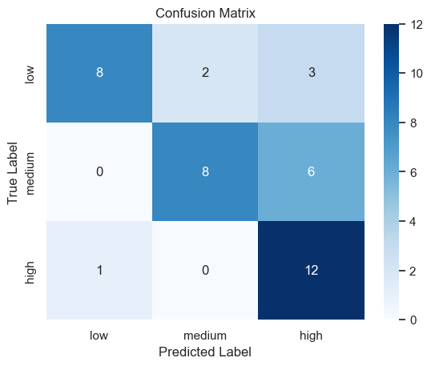

```
              precision    recall  f1-score   support

           0       0.89      0.62      0.73        13
           1       0.80      0.57      0.67        14
           2       0.57      0.92      0.71        13

    accuracy                           0.70        40
   macro avg       0.75      0.70      0.70        40
weighted avg       0.75      0.70      0.70        40
```

```python
y_pred = grid.predict(X_test)

cm = confusion_matrix(y_test, y_pred)
sns.heatmap(cm, annot = True, xticklabels =classes, yticklabels = classes, cmap = 'Blues')
plt.xlabel('Predicted Label')
plt.ylabel('True Label')
plt.title('Confusion Matrix')
plt.show()

print(classification_report(y_test, y_pred))
```

GaussianNB appears to be a worse predictor than KNN for this dataset. How about if we retry without the gender columns?

```python
X = mall_knn[['age', 'income']]
y = mall_knn.spending_level

X_train, X_test, y_train, y_test = train_test_split(
    X,
    y,
    test_size=0.2,
    random_state = 13,
    stratify = y
)
```

```python
params = {
    'var_smoothing' : np.logspace(0, -9, num = 100)
}

grid = GridSearchCV(
    estimator= GaussianNB(),
    param_grid=params,
    cv = cv,
    scoring = 'accuracy',
    n_jobs = -1
)

grid.fit(X_train, y_train)

print("Best parameters found:", grid.best_params_)
print(f"Best CV Score: {grid.best_score_:.4f}")

accuracy = grid.score(X_test, y_test)
print(f"Accuracy: {accuracy:.4f}")
```

```
Best parameters found: {'var_smoothing': np.float64(0.008111308307896872)}
Best CV Score: 0.7438
Accuracy: 0.7500
```

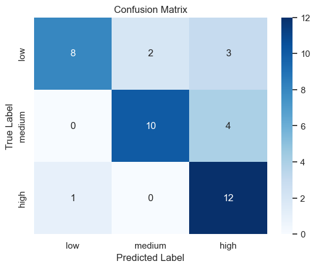

```
              precision    recall  f1-score   support

           0       0.89      0.62      0.73        13
           1       0.83      0.71      0.77        14
           2       0.63      0.92      0.75        13

    accuracy                           0.75        40
   macro avg       0.78      0.75      0.75        40
weighted avg       0.79      0.75      0.75        40
```

```python
y_pred = grid.predict(X_test)

cm = confusion_matrix(y_test, y_pred)
sns.heatmap(cm, annot = True, xticklabels =classes, yticklabels = classes, cmap = 'Blues')
plt.xlabel('Predicted Label')
plt.ylabel('True Label')
plt.title('Confusion Matrix')
plt.show()

print(classification_report(y_test, y_pred))
```

A little better. I don't think there's much else to do besides maybe convert the income and age columns into binary, and try a Bernoulli NB?

### BernoulliNB

```python
mall.head()
```

|  | gender | age | income | spending_score | spending_level |
| --- | --- | --- | --- | --- | --- |
| 0 | Male | 19 | 15 | 39 | low |
| 1 | Male | 21 | 15 | 81 | high |
| 2 | Female | 20 | 16 | 6 | low |
| 3 | Female | 23 | 16 | 77 | high |
| 4 | Female | 31 | 17 | 40 | low |

```python
mall_knn.head()
```

|  | age | income | spending_score | spending_level | gender_Female | gender_Male |
| --- | --- | --- | --- | --- | --- | --- |
| 0 | -1.424569 | -1.738999 | 39 | 0 | 0 | 1 |
| 1 | -1.281035 | -1.738999 | 81 | 2 | 0 | 1 |
| 2 | -1.352802 | -1.700830 | 6 | 0 | 1 | 0 |
| 3 | -1.137502 | -1.700830 | 77 | 2 | 1 | 0 |
| 4 | -0.563369 | -1.662660 | 40 | 0 | 1 | 0 |

```python
mall_bnb = pd.concat([mall[['age', 'income', 'spending_level']], mall_knn[['gender_Female', 'gender_Male']]], axis = 1)
```

```python
mall_bnb
```

|  | age | income | spending_level | gender_Female | gender_Male |
| --- | --- | --- | --- | --- | --- |
| 0 | 19 | 15 | low | 0 | 1 |
| 1 | 21 | 15 | high | 0 | 1 |
| 2 | 20 | 16 | low | 1 | 0 |
| 3 | 23 | 16 | high | 1 | 0 |
| 4 | 31 | 17 | low | 1 | 0 |
| ... | ... | ... | ... | ... | ... |
| 195 | 35 | 120 | high | 1 | 0 |
| 196 | 45 | 126 | low | 1 | 0 |
| 197 | 32 | 126 | high | 0 | 1 |
| 198 | 32 | 137 | low | 0 | 1 |
| 199 | 30 | 137 | high | 0 | 1 |

200 rows × 5 columns

To prepare the dataset for BernoulliNB I'm going to convert the income and age columns into binary. I'll separate income by the median income. Anything above or equal will be 1, else 0. I'll do the same for age.

```python
age_median = mall.age.median()
income_median = mall.income.median()

mall_bnb.loc[mall['age'] < age_median ,'age_binary'] = 0
mall_bnb.loc[mall['age'] >= age_median ,'age_binary'] = 1

mall_bnb.loc[mall['income'] < income_median ,'income_binary'] = 0
mall_bnb.loc[mall['income'] >= income_median ,'income_binary'] = 1
```

```python
mall_bnb.head()
```

|  | age | income | spending_level | gender_Female | gender_Male | age_binary | income_binary |
| --- | --- | --- | --- | --- | --- | --- | --- |
| 0 | 19 | 15 | low | 0 | 1 | 0.0 | 0.0 |
| 1 | 21 | 15 | high | 0 | 1 | 0.0 | 0.0 |
| 2 | 20 | 16 | low | 1 | 0 | 0.0 | 0.0 |
| 3 | 23 | 16 | high | 1 | 0 | 0.0 | 0.0 |
| 4 | 31 | 17 | low | 1 | 0 | 0.0 | 0.0 |

```python
X = mall_bnb[['gender_Male', 'gender_Female', 'age_binary', 'income_binary']].copy()
y = mall_knn['spending_level']

X_train, X_test, y_train, y_test = train_test_split(
    X,
    y,
    test_size=0.2,
    random_state = 13,
    stratify = y
)


model = BernoulliNB()

model.fit(X_train, y_train)

y_pred = model.predict(X_test)

accuracy = accuracy_score(y_test, y_pred)
print("Test set accuracy:", accuracy)
```

```
Test set accuracy: 0.5
```

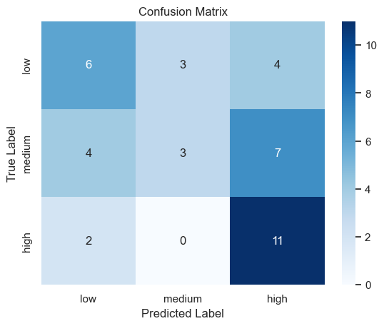

```
              precision    recall  f1-score   support

           0       0.50      0.46      0.48        13
           1       0.50      0.21      0.30        14
           2       0.50      0.85      0.63        13

    accuracy                           0.50        40
   macro avg       0.50      0.51      0.47        40
weighted avg       0.50      0.50      0.47        40
```

```python
cm = confusion_matrix(y_test, y_pred)
sns.heatmap(cm, annot = True, xticklabels =classes, yticklabels = classes, cmap = 'Blues')
plt.xlabel('Predicted Label')
plt.ylabel('True Label')
plt.title('Confusion Matrix')
plt.show()

print(classification_report(y_test, y_pred))
```

Haha, that's pretty bad. It's almost as bad as picking randomly. The only thing that saves it is that the model has good recall for high (predicts positive cases correctly). Buuuut it also has really low precision for high; out of the 22 times it predicted high, only 11 of them were correct. I'll try again with a gridsearch.

```python
params = param_grid = {
    'alpha': [0.1, 0.5, 1.0, 2.0, 5.0],
    'fit_prior': [True, False]
}

grid = GridSearchCV(
    estimator = BernoulliNB(),
    param_grid = params,
    cv = cv,
    scoring = 'accuracy',
    n_jobs = -1,
    verbose = 2
)

grid.fit(X_train, y_train)

print("Best parameters found:", grid.best_params_)
print(f"Best CV Score: {grid.best_score_:.4f}")

accuracy = grid.score(X_test, y_test)
print(f"Accuracy: {accuracy:.4f}")
```

```
Fitting 5 folds for each of 10 candidates, totalling 50 fits
Best parameters found: {'alpha': 0.1, 'fit_prior': True}
Best CV Score: 0.5312
Accuracy: 0.5000
```

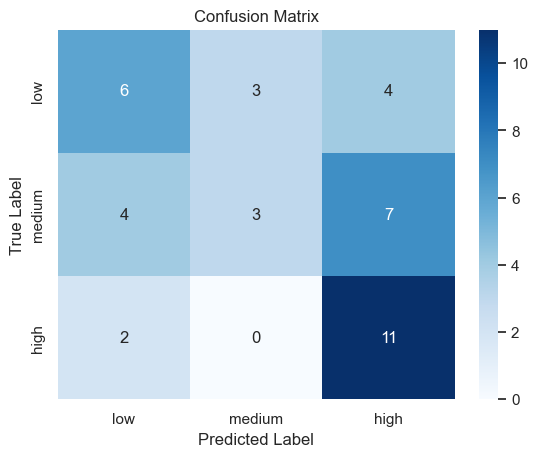

```
              precision    recall  f1-score   support

           0       0.50      0.46      0.48        13
           1       0.50      0.21      0.30        14
           2       0.50      0.85      0.63        13

    accuracy                           0.50        40
   macro avg       0.50      0.51      0.47        40
weighted avg       0.50      0.50      0.47        40
```

```python
y_pred = grid.predict(X_test)

cm = confusion_matrix(y_test, y_pred)
sns.heatmap(cm, annot = True, xticklabels =classes, yticklabels = classes, cmap = 'Blues')

plt.xlabel('Predicted Label')
plt.ylabel('True Label')
plt.title('Confusion Matrix')
plt.show()

print(classification_report(y_test, y_pred))
```

No difference. One last try before moving on. Instead of manually selecting the threshold value to binarize age and income, I'll use gridsearch to try multiple thresholds.  
First, I'll normalize the age and income columns with a min-max scalar to make their ranges match. I'll apply the scalar and model in a pipeline this time.

```python
X = pd.concat([mall[['age', 'income']], mall_knn[['gender_Female', 'gender_Male']]], axis = 1)
y = mall_knn.spending_level

X_train, X_test, y_train, y_test = train_test_split(
    X,
    y,
    test_size=0.2,
    random_state = 13,
    stratify = y
)
```

```python
pipeline = Pipeline([
    ('scalar', MinMaxScaler()),
    ('bnb', BernoulliNB())
])

params = param_grid = {
    'bnb__alpha': [0.1, 0.5, 1.0, 2.0, 5.0],
    'bnb__fit_prior': [True, False],
    'bnb__binarize' : [i/10 for i in range(0,11)]
}

grid = GridSearchCV(
    pipeline,
    param_grid = params,
    cv = cv,
    scoring = 'accuracy',
    n_jobs = -1,
    verbose = 2
)

grid.fit(X_train, y_train)

print("Best parameters found:", grid.best_params_)
print(f"Best CV Score: {grid.best_score_:.4f}")

accuracy = grid.score(X_test, y_test)
print(f"Accuracy: {accuracy:.4f}")
```

```
Fitting 5 folds for each of 110 candidates, totalling 550 fits
Best parameters found: {'bnb__alpha': 0.1, 'bnb__binarize': 0.4, 'bnb__fit_prior': True}
Best CV Score: 0.5500
Accuracy: 0.5750
```

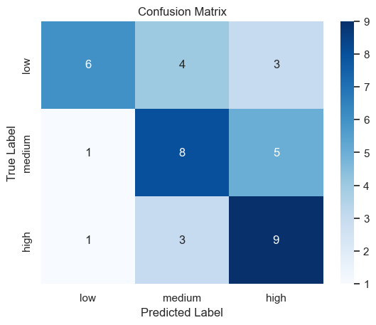

```
              precision    recall  f1-score   support

           0       0.75      0.46      0.57        13
           1       0.53      0.57      0.55        14
           2       0.53      0.69      0.60        13

    accuracy                           0.57        40
   macro avg       0.60      0.58      0.57        40
weighted avg       0.60      0.57      0.57        40
```

```python
y_pred = grid.predict(X_test)

cm = confusion_matrix(y_test, y_pred)
sns.heatmap(cm, annot = True, xticklabels =classes, yticklabels = classes, cmap = 'Blues')
plt.xlabel('Predicted Label')
plt.ylabel('True Label')
plt.title('Confusion Matrix')
plt.show()

print(classification_report(y_test, y_pred))
```

Yeah, this ain't it. A simple binary does not adequately capture the relationships between income or age and spending level. I'm going to move on to unsupervised algorithms now.

```python
## Supervised Sumamry
```

# Unsupervised Algorithms

## K-Means

```python
mall_kmeans = pd.concat([mall[['age','income', 'spending_score', 'gender']], mall_knn[['gender_Male', 'gender_Female',]]], axis = 1)

scaler = StandardScaler()
mall_kmeans[['age_std', 'income_std','spending_std']] = scaler.fit_transform(mall_kmeans[['age', 'income', 'spending_score']])

X = mall_kmeans[['age_std', 'income_std','spending_std', 'gender_Male', 'gender_Female']]
X.head()
```

|  | age_std | income_std | spending_std | gender_Male | gender_Female |
| --- | --- | --- | --- | --- | --- |
| 0 | -1.424569 | -1.738999 | -0.434801 | 1 | 0 |
| 1 | -1.281035 | -1.738999 | 1.195704 | 1 | 0 |
| 2 | -1.352802 | -1.700830 | -1.715913 | 0 | 1 |
| 3 | -1.137502 | -1.700830 | 1.040418 | 0 | 1 |
| 4 | -0.563369 | -1.662660 | -0.395980 | 0 | 1 |

```python
model = KMeans(n_clusters = 3, random_state=13)

mall_kmeans['cluster'] = model.fit_predict(X)
```

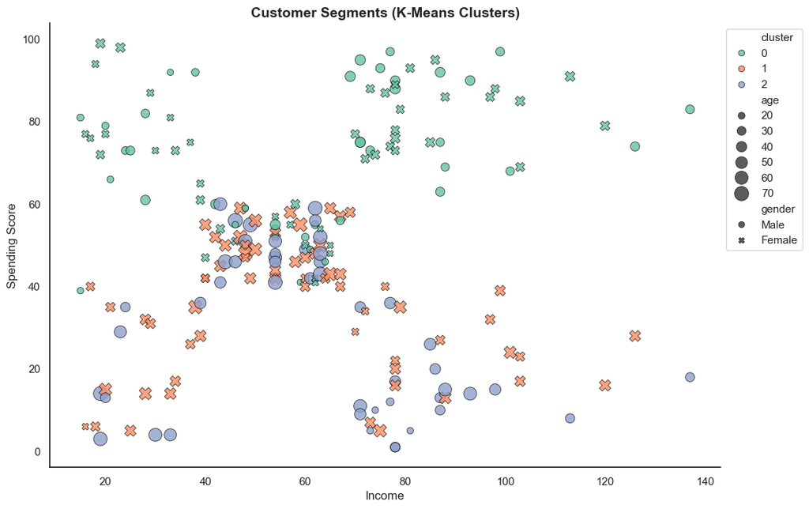

```python
sns.set(style="white")

fig, ax = plt.subplots(figsize=(12, 8))  # bigger figure for clarity

sns.scatterplot(
    data=mall_kmeans,
    x="income",
    y="spending_score",
    hue="cluster",
    style="gender",
    size="age",
    sizes=(40, 200),  # control size range
    palette="Set2",
    alpha=0.8,         # slight transparency
    edgecolor="black"   # give markers some definition
)

ax.grid(False)

plt.title("Customer Segments (K-Means Clusters)", fontsize=14, weight = 'bold')
plt.xlabel("Income")
plt.ylabel("Spending Score")
plt.legend(bbox_to_anchor=(1, 1), loc='upper left',)  # move legend

sns.despine(ax=ax)

plt.show()
```

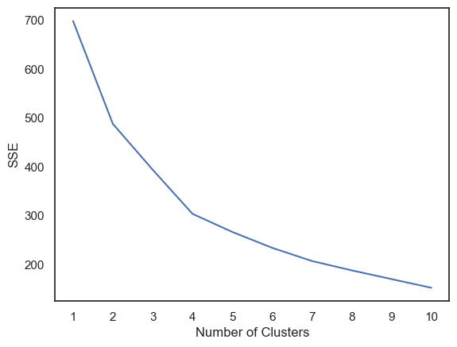

```python
#initialize kmeans parameters
kmeans_kwargs = {
"init": "random",
"n_init": 10
}

#create list to hold SSE values for each k
sse = []
for k in range(1, 11):
    kmeans = KMeans(n_clusters=k, **kmeans_kwargs)
    kmeans.fit(X)
    sse.append(kmeans.inertia_)

#visualize results
plt.plot(range(1, 11), sse)
plt.xticks(range(1, 11))
plt.xlabel("Number of Clusters")
plt.ylabel("SSE")
plt.show()
```

I spy an elbow at 4.

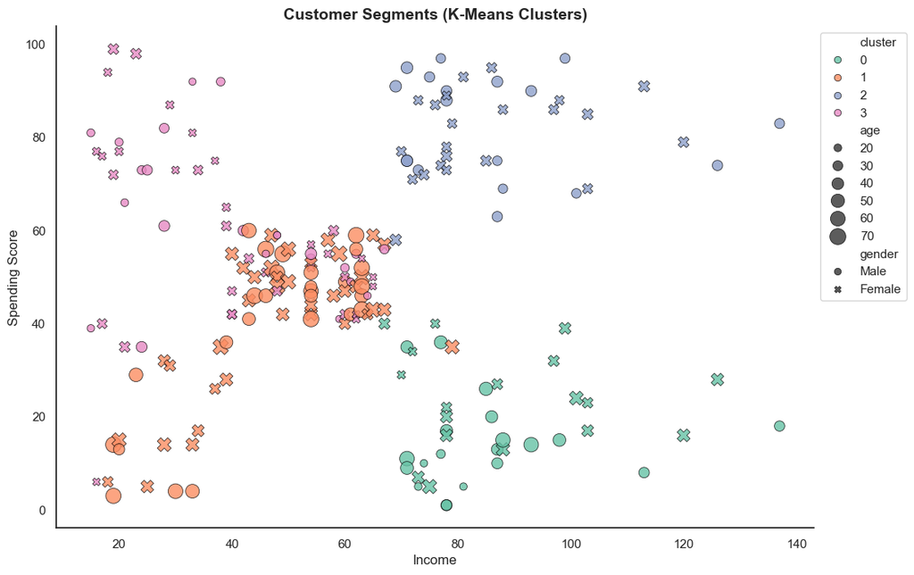

```python
model = KMeans(
    n_clusters = 4
)

mall_kmeans['cluster'] = model.fit_predict(X)


sns.set(style="white")

fig, ax = plt.subplots(figsize=(12, 8))  # bigger figure for clarity

sns.scatterplot(
    data=mall_kmeans,
    x="income",
    y="spending_score",
    hue="cluster",
    style="gender",
    size="age",
    sizes=(40, 200),  # control size range
    palette="Set2",
    alpha=0.8,         # slight transparency
    edgecolor="black"   # give markers some definition
)

ax.grid(False)

plt.title("Customer Segments (K-Means Clusters)", fontsize=14, weight = 'bold')
plt.xlabel("Income")
plt.ylabel("Spending Score")
plt.legend(bbox_to_anchor=(1, 1), loc='upper left',)  # move legend

sns.despine(ax=ax)

plt.show()
```

```python
mall_kmeans.cluster.value_counts()
```

```
cluster
1    65
3    57
2    40
0    38
Name: count, dtype: int64
```

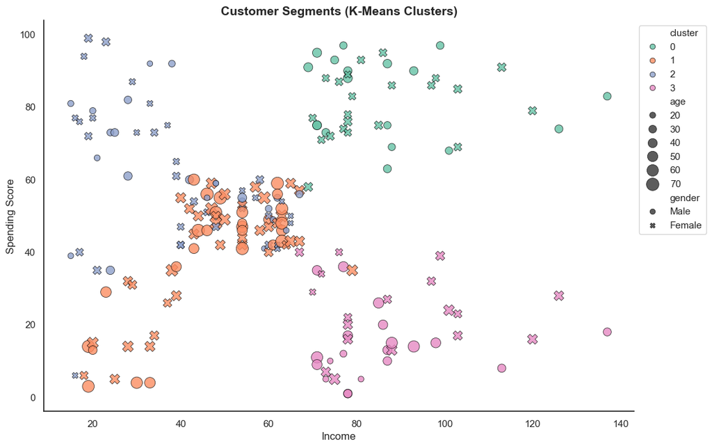

```python
model = KMeans(
    n_clusters = 4,
    init = 'k-means++',
    n_init=10,
    max_iter=300,
    random_state = 13
)

mall_kmeans['cluster'] = model.fit_predict(X)


sns.set(style="white")

fig, ax = plt.subplots(figsize=(12, 8))  # bigger figure for clarity

sns.scatterplot(
    data=mall_kmeans,
    x="income",
    y="spending_score",
    hue="cluster",
    style="gender",
    size="age",
    sizes=(40, 200),  # control size range
    palette="Set2",
    alpha=0.8,         # slight transparency
    edgecolor="black"   # give markers some definition
)

ax.grid(False)

plt.title("Customer Segments (K-Means Clusters)", fontsize=14, weight = 'bold')
plt.xlabel("Income")
plt.ylabel("Spending Score")
plt.legend(bbox_to_anchor=(1, 1), loc='upper left',)  # move legend

sns.despine(ax=ax)

plt.show()
```

```python
mall_kmeans.cluster.value_counts()
```

```
cluster
1    65
2    57
0    40
3    38
Name: count, dtype: int64
```

Cluster 0 appears to consist of middle age folk with high income and high spending score.  
Cluster 1 appears to be older, with an average or below income with an average or below spending score  
Cluster 2 appears to 20 - 40, with an average or below income and an average or higher than average spending score, and mostly female  
Cluster 3 appear to be shoppers with higher than average income and lower than average spending score.  
Further work on this data would be to closely analyze the shoppers grouped in these clusters and attempt to glean further insight by a deeper analysis. But, I want to try the next unsupervised model so we'll leave this as a cursory analysis of the graph.

## Agglomerative Clustering

Agglomerative Clustering is a type of Hierarchical Clustering, which is a type of clustering that links a dataset by a measure of similarity. Agglomerative just means that the algorithm starts with a cluster for each datapoint and starts linking them. The 2nd type of Hierarchical Clustering called Partial Clustering, starts with one cluster and breaks it into smaller and smaller clusters based on the similarity between points. This will do exactly the same as kmeans but in a different way.

I'm going to use the mall_kmeans dataframe again, and the same X I built in KMeans.

```python
X.head()
```

|  | age_std | income_std | spending_std | gender_Male | gender_Female |
| --- | --- | --- | --- | --- | --- |
| 0 | -1.424569 | -1.738999 | -0.434801 | 1 | 0 |
| 1 | -1.281035 | -1.738999 | 1.195704 | 1 | 0 |
| 2 | -1.352802 | -1.700830 | -1.715913 | 0 | 1 |
| 3 | -1.137502 | -1.700830 | 1.040418 | 0 | 1 |
| 4 | -0.563369 | -1.662660 | -0.395980 | 0 | 1 |

```python
model = AgglomerativeClustering(n_clusters=3)

mall_kmeans["agglo_cluster"] = model.fit_predict(X)
```

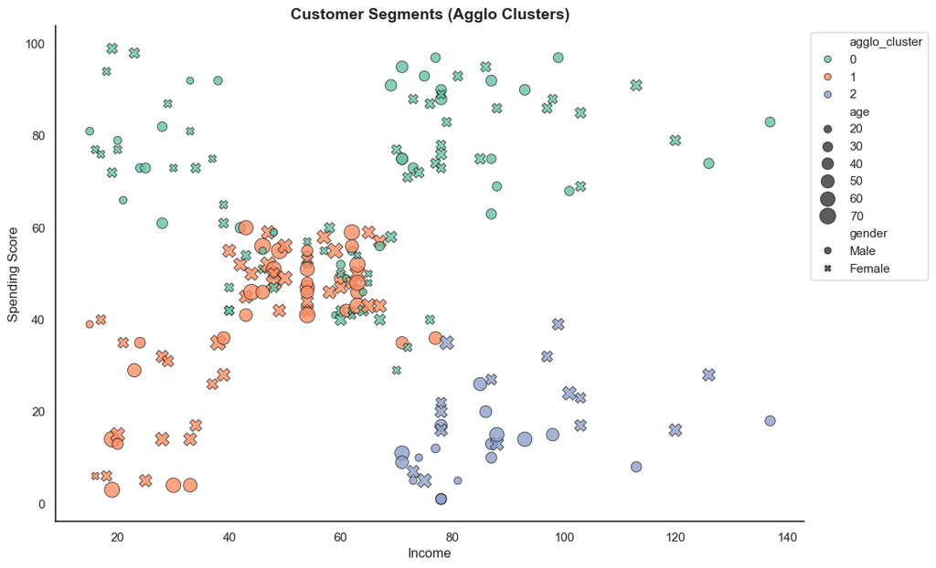

```python
sns.set(style="white")

fig, ax = plt.subplots(figsize=(12, 8))
sns.scatterplot(
    data=mall_kmeans,
    x="income",
    y="spending_score",
    hue="agglo_cluster",
    style="gender",
    size="age",
    sizes=(40, 200),
    palette="Set2",
    alpha=0.8,
    edgecolor="black"
)

ax.grid(False)

plt.title("Customer Segments (Agglo Clusters)", fontsize=14, weight = 'bold')
plt.xlabel("Income")
plt.ylabel("Spending Score")
plt.legend(bbox_to_anchor=(1, 1), loc='upper left',)

sns.despine(ax=ax)

plt.show()
```

```python
mall_kmeans.agglo_cluster.value_counts()
```

```
agglo_cluster
0    97
1    70
2    33
Name: count, dtype: int64
```

This actually looks pretty close to the first K-Means cluster. (After further research this makes sense: the sklearn function by default is using Euclidean distance to calculate similarity and is minimizing the variance between datapoints in each cluster, same as KMeans) I'll continue tuning to see if any more patterns emerge.  
And apparently sklearn doesn't have a pipeline to test parameters like GridSearchCV.

There are many parameters I can adjust when using the agglomeratrive clustering function. I'll create a loop to evaluate the models based on n_clusters (number of clusters to produce), linkage method (how to connect clusters), and affinity metric (how distance is measured b/w points).  
But first let's print out some pretty dendrograms.  
These are visual representations of how the algorithm is building clusters from the ground up.

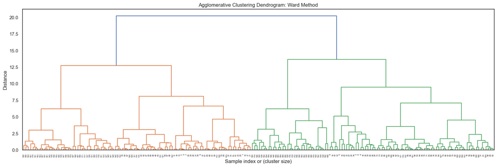

```python
link = linkage(X, method='ward')

plt.figure(figsize=(20, 6))
tree = dendrogram(link)
plt.title("Agglomerative Clustering Dendrogram: Ward Method")
plt.xlabel("Sample index or (cluster size)")
plt.ylabel("Distance")
plt.show()
```

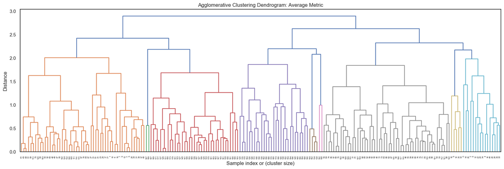

```python
link = linkage(X, method='average')

plt.figure(figsize=(20, 6))
tree = dendrogram(link)
plt.title("Agglomerative Clustering Dendrogram: Average Metric")
plt.xlabel("Sample index or (cluster size)")
plt.ylabel("Distance")
plt.show()
```

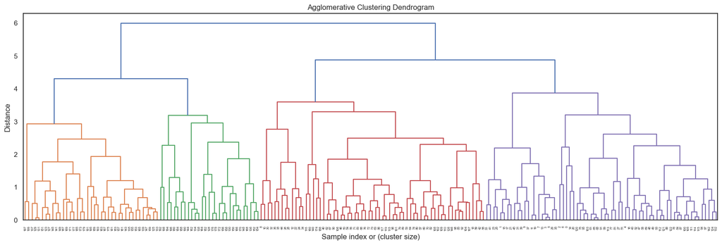

```python
link = linkage(X, method='complete')

plt.figure(figsize=(20, 6))
tree = dendrogram(link)
plt.title("Agglomerative Clustering Dendrogram")
plt.xlabel("Sample index or (cluster size)")
plt.ylabel("Distance")
plt.show()
```

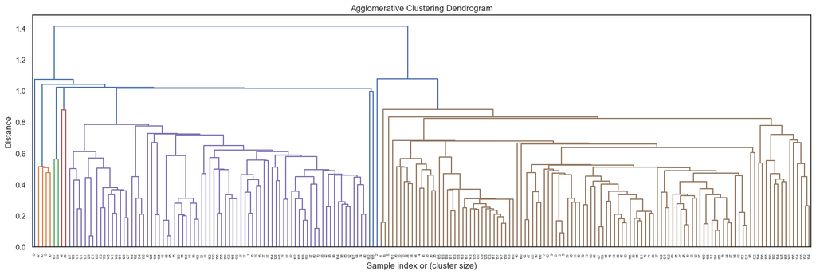

```python
link = linkage(X, method='single')

plt.figure(figsize=(20, 6))
tree = dendrogram(link)
plt.title("Agglomerative Clustering Dendrogram")
plt.xlabel("Sample index or (cluster size)")
plt.ylabel("Distance")
plt.show()
```

Now, we'll use the silhouette metric to measure the model. Silhouette is a measure of how close the points are to each other in a cluster and how far they are from the nearest cluster.

```python
linkage_method = ['average', 'complete','single']
affinity_metric = ['euclidean', 'manhattan', 'cosine']
sils = []

for k in range(2,11):
    for link in linkage_method:
        for affinity in affinity_metric:
            model = AgglomerativeClustering(n_clusters=k, linkage=link, metric = affinity)
            labels = model.fit_predict(X)
            score = silhouette_score(X, labels)
            sils.append({
                    'linkage': link,
                    'affinity': affinity,
                    'n_clusters': k,
                    'silhouette': score
                })

for k in range(2,11):
    model = AgglomerativeClustering(n_clusters=k, linkage='ward', metric = 'euclidean')
    labels = model.fit_predict(X)
    score = silhouette_score(X, labels)
    sils.append({
                    'linkage': 'ward',
                    'affinity': 'euclidean',
                    'n_clusters': k,
                    'silhouette': score
                })
```

```python
sil_score = pd.DataFrame(sils)
```

```python
sil_score['silhouette'].sort_values(ascending = False)
```

```
89    0.354319
88    0.337178
73    0.322561
56    0.319682
27    0.317403
        ...
62   -0.018656
80   -0.020378
69   -0.027595
78   -0.046283
26   -0.067553
Name: silhouette, Length: 90, dtype: float64
```

```python
sil_score.loc[sil_score['silhouette'].idxmax()]
```

```
linkage            ward
affinity      euclidean
n_clusters           10
silhouette     0.354319
Name: 89, dtype: object
```

Sooo it looks like ward with euclidean and 10 clusters has the best silhouette score. I will note that the silhouette scores are relatively low. I'll take a peek at the results.

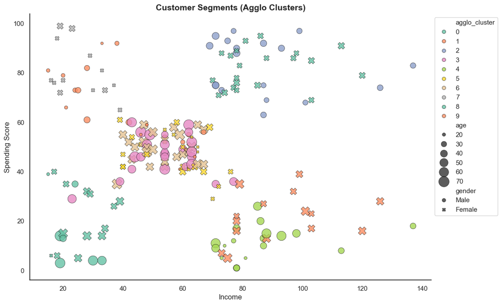

```python
model = AgglomerativeClustering(n_clusters=10)

mall_kmeans["agglo_cluster"] = model.fit_predict(X)

sns.set(style="white")

fig, ax = plt.subplots(figsize=(12, 8))
sns.scatterplot(
    data=mall_kmeans,
    x="income",
    y="spending_score",
    hue="agglo_cluster",
    style="gender",
    size="age",
    sizes=(20, 300),
    palette="Set2",
    alpha=0.8,
    edgecolor="black"
)

ax.grid(False)

plt.title("Customer Segments (Agglo Clusters)", fontsize=14, weight = 'bold')
plt.xlabel("Income")
plt.ylabel("Spending Score")
plt.legend(bbox_to_anchor=(1, 1), loc='upper left',)

sns.despine(ax=ax)

plt.show()
```

I'm wondering if we would see similar results with KMeans and 10 clusters.

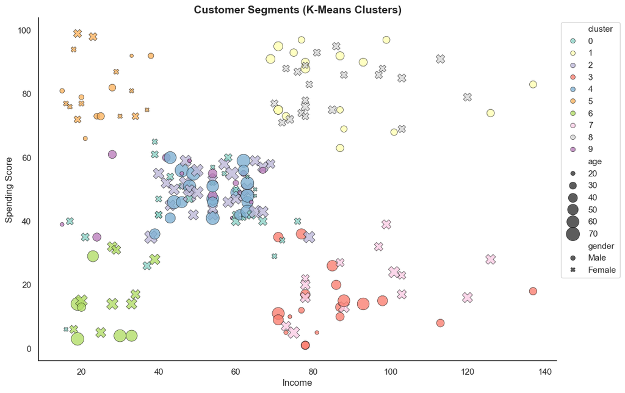

```python
model = KMeans(
    n_clusters = 10,
    init = 'k-means++',
    n_init=10,
    max_iter=300,
    random_state = 13
)

mall_kmeans['cluster'] = model.fit_predict(X)


sns.set(style="white")

fig, ax = plt.subplots(figsize=(12, 8))  # bigger figure for clarity

sns.scatterplot(
    data=mall_kmeans,
    x="income",
    y="spending_score",
    hue="cluster",
    style="gender",
    size="age",
    sizes=(20, 300),  # control size range
    palette="Set3",
    alpha=0.8,         # slight transparency
    edgecolor="black"   # give markers some definition
)

ax.grid(False)

plt.title("Customer Segments (K-Means Clusters)", fontsize=14, weight = 'bold')
plt.xlabel("Income")
plt.ylabel("Spending Score")
plt.legend(bbox_to_anchor=(1, 1), loc='upper left',)  # move legend

sns.despine(ax=ax)

plt.show()
```

```python
sum(mall_kmeans['cluster'] == mall_kmeans['agglo_cluster'])
```

```
27
```